# Convolutional Networks

```python
from __future__ import absolute_import, division, print_function

# TODO: Swallow output
!pip -q install pydot_ng
#!pip -q install graphviz
#!apt install graphviz > /dev/null

from keras.layers import BatchNormalization
import tensorflow as tf
import tensorflow.contrib.eager as tfe
import numpy as np
import matplotlib.pyplot as plt
from IPython import display
%matplotlib inline

try:
  tf.enable_eager_execution()
  print('Running in Eager mode.')
except ValueError:
  print('Already running in Eager mode')
```

```
Running in Eager mode.
```

```python
import keras
from keras.models import Sequential
from keras.utils import np_utils
from keras.preprocessing.image import ImageDataGenerator
from keras.layers import Dense, Activation, Flatten, Dropout, BatchNormalization
from keras.layers import Conv2D, MaxPooling2D
from keras.datasets import cifar10
from keras import regularizers
from keras.callbacks import LearningRateScheduler
import numpy as np
```

## Convolutional Architectures

When modelling an image using a regular feed-forward network, we find that the number of model parameters grows exponentially.

**QUESTION**: How many parameters would there be in a feed-forward network with 2 hidden layers consisting of 512 and 256 neurons respectively, an output size of 10 and an input image of shape [32, 32, 3]? (Note that we represent each pixel in a a colour image using three real-numbers for the Red, Green and Blue values and hence the 32x32**x3** shape.)

ConvNets address this model parameter issue by exploiting structure in the inputs to the network (in particular, by making the assumption that the input is a 3-D *volume*, which applies to images for example, where the 3 dimensions consist of the three RGB channels). The two key differences between a ConvNet and a Feed-forward network are:

- ConvNets have neurons that are arranged in 3 dimensions: width, height, depth. Note that *depth* here means channels, i.e. the depth of the input volume, not the depth of a deep neural network!
- The neurons in each layer are only connected to a small region of the layer before it.

### Aside: The rise of deep convolutional architectures

ConvNet architectures were key to the tremendous success of deep learning in machine vision. In particular, the first deep learning model to win the ImageNet competition in 2012 was called AlexNet (after Alex Krizhevsky, one of its inventors). It had 5 convolutional layers followed by 3 fully-connected layers. Later winners included GoogLeNet and ResNet. If you're curious, have a look at [this link](https://medium.com/towards-data-science/neural-network-architectures-156e5bad51ba) for a great summary of different ConvNet architectures.

### Convolutional Layers

The hyper-parameters of a convolutional layer are as follows:

- **Filters** defines the number of filters in the layer
- **Kernel Size** defines the width and height of the filters (also called "kernels") in the layer. Note that kernels always have the same depth as the inputs to the layer.
- **Stride** defines the number of pixels by which we move the filter when "sliding" it along the input volume. Typically this value would be 1, but values of 2 and 3 are also sometimes used.
- **Padding** refers to the addition of 0-value pixels to the edges of the input volume along the width and height dimensions. In Tensorflow you can set this to "VALID", which essentially does no padding or "SAME" which pads the input such that the output width and height are the same as the input.

## The CIFAR10 Dataset

Now that we understand convolutional, max-pooling and feed-forward layers, we can combine these as building block to build a ConvNet classifier for images. For this practical, we will use the colour image dataset CIFAR10 (pronounced "seefar ten") which consists of 50,000 training images and 10,000 test images. As we did in Practical 1, we take 10,000 images from the training set to form a validation set and visualise some example images.

```python
cifar = tf.keras.datasets.cifar10
(train_images, train_labels), (test_images, test_labels) = cifar.load_data()
cifar_labels = ['airplane', 'automobile', 'bird', 'cat', 'deer', 'dog', 'frog', 'horse', 'ship', 'truck']
```

```python
# Take the last 10000 images from the training set to form a validation set
train_labels = train_labels.squeeze()
validation_images = train_images[-10000:, :, :]
validation_labels = train_labels[-10000:]
train_images = train_images[:-10000, :, :]
train_labels = train_labels[:-10000]
```

What are the shapes and data-types of train_images and train_labels?

```python
print('train_images.shape = {}, data-type = {}'.format(train_images.shape, train_images.dtype))
print('train_labels.shape = {}, data-type = {}'.format(train_labels.shape, train_labels.dtype))

print('validation_images.shape = {}, data-type = {}'.format(validation_images.shape, validation_images.dtype))
print('validation_labels.shape = {}, data-type = {}'.format(validation_labels.shape, validation_labels.dtype))
```

```
train_images.shape = (40000, 32, 32, 3), data-type = uint8
train_labels.shape = (40000,), data-type = uint8
validation_images.shape = (10000, 32, 32, 3), data-type = uint8
validation_labels.shape = (10000,), data-type = uint8
```

### Visualise examples from the dataset

Run the cell below multiple times to see various images. (They might look a bit blurry because we've blown up the small images.)

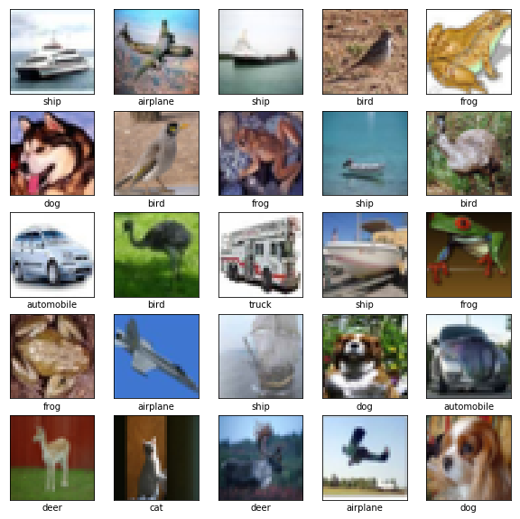

```python
plt.figure(figsize=(10,10))
for i in range(25):
  plt.subplot(5,5,i+1)
  plt.xticks([])
  plt.yticks([])
  plt.grid('off')

  img_index = np.random.randint(0, 40000)
  plt.imshow(train_images[img_index])
  plt.xlabel(cifar_labels[train_labels[img_index]])
```

## A ConvNet Classifier

Finally, we build a simple convolutional architecture to classify the CIFAR images. We will build a mini version of the AlexNet architecture, which consists of 5 convolutional layers with max-pooling, followed by 3 fully-connected layers at the end. In order to investigate the effect each of these two layers have on the number of parameters, we'll build the model in two stages.

First, the convolutional layers + max-pooling:

```python
# Define the convolutinal part of the model architecture using Keras Layers.
model = tf.keras.models.Sequential([
    tf.keras.layers.Conv2D(filters=48, kernel_size=(3, 3), activation=tf.nn.relu, input_shape=(32, 32, 3), padding='same'),
    tf.keras.layers.MaxPooling2D(pool_size=(3, 3)),
    tf.keras.layers.Conv2D(filters=128, kernel_size=(3, 3), activation=tf.nn.relu, padding='same'),
    tf.keras.layers.MaxPooling2D(pool_size=(3, 3)),
    tf.keras.layers.Conv2D(filters=192, kernel_size=(3, 3), activation=tf.nn.relu, padding='same'),
    tf.keras.layers.Conv2D(filters=192, kernel_size=(3, 3), activation=tf.nn.relu, padding='same'),
    tf.keras.layers.Conv2D(filters=128, kernel_size=(3, 3), activation=tf.nn.relu, padding='same'),
    tf.keras.layers.MaxPooling2D(pool_size=(3, 3)),
])
```

```
WARNING:tensorflow:From C:\ProgramData\Anaconda3\lib\site-packages\tensorflow\python\ops\resource_variable_ops.py:642: colocate_with (from tensorflow.python.framework.ops) is deprecated and will be removed in a future version.
Instructions for updating:
Colocations handled automatically by placer.
```

How many parameters are there in the convolutional part of the architecture? We can easily inspect this using the model summary function in Keras:

```python
model.summary()
```

```
_________________________________________________________________
Layer (type)                 Output Shape              Param #
=================================================================
conv2d (Conv2D)              (None, 32, 32, 48)        1344
_________________________________________________________________
max_pooling2d (MaxPooling2D) (None, 10, 10, 48)        0
_________________________________________________________________
conv2d_1 (Conv2D)            (None, 10, 10, 128)       55424
_________________________________________________________________
max_pooling2d_1 (MaxPooling2 (None, 3, 3, 128)         0
_________________________________________________________________
conv2d_2 (Conv2D)            (None, 3, 3, 192)         221376
_________________________________________________________________
conv2d_3 (Conv2D)            (None, 3, 3, 192)         331968
_________________________________________________________________
conv2d_4 (Conv2D)            (None, 3, 3, 128)         221312
_________________________________________________________________
max_pooling2d_2 (MaxPooling2 (None, 1, 1, 128)         0
=================================================================
Total params: 831,424
Trainable params: 831,424
Non-trainable params: 0
_________________________________________________________________
```

Now we add a fully-connected part. Note that we also add "Dropout" after the first fully-connected layer. Dropout is a regularization technique which randomly zeros out ("drops") connections between neurons, and it was one of the key innovations of the AlexNet paper in 2012.

```python
model.add(tf.keras.layers.Flatten())  # Flatten "squeezes" a 3-D volume down into a single vector.
model.add(tf.keras.layers.Dense(1024, activation=tf.nn.relu))
model.add(tf.keras.layers.Dropout(rate=0.5))
model.add(tf.keras.layers.Dense(1024, activation=tf.nn.relu))
model.add(tf.keras.layers.Dense(10, activation=tf.nn.softmax))
```

```
WARNING:tensorflow:From C:\ProgramData\Anaconda3\lib\site-packages\tensorflow\python\keras\layers\core.py:143: calling dropout (from tensorflow.python.ops.nn_ops) with keep_prob is deprecated and will be removed in a future version.
Instructions for updating:
Please use `rate` instead of `keep_prob`. Rate should be set to `rate = 1 - keep_prob`.
```

```python
model.summary()
```

```
_________________________________________________________________
Layer (type)                 Output Shape              Param #
=================================================================
conv2d (Conv2D)              (None, 32, 32, 48)        1344
_________________________________________________________________
max_pooling2d (MaxPooling2D) (None, 10, 10, 48)        0
_________________________________________________________________
conv2d_1 (Conv2D)            (None, 10, 10, 128)       55424
_________________________________________________________________
max_pooling2d_1 (MaxPooling2 (None, 3, 3, 128)         0
_________________________________________________________________
conv2d_2 (Conv2D)            (None, 3, 3, 192)         221376
_________________________________________________________________
conv2d_3 (Conv2D)            (None, 3, 3, 192)         331968
_________________________________________________________________
conv2d_4 (Conv2D)            (None, 3, 3, 128)         221312
_________________________________________________________________
max_pooling2d_2 (MaxPooling2 (None, 1, 1, 128)         0
_________________________________________________________________
flatten (Flatten)            (None, 128)               0
_________________________________________________________________
dense (Dense)                (None, 1024)              132096
_________________________________________________________________
dropout (Dropout)            (None, 1024)              0
_________________________________________________________________
dense_1 (Dense)              (None, 1024)              1049600
_________________________________________________________________
dense_2 (Dense)              (None, 10)                10250
=================================================================
Total params: 2,023,370
Trainable params: 2,023,370
Non-trainable params: 0
_________________________________________________________________
```

### Aside: Random initialization schemes

You might have wondered what values we are using for the initial values of the weights and biases in our model. The short answer is that we typically use random initialization. In this case, we have just been using the default keras initializers for each layer, which are usually sufficient.

The longer answer is that just using completely random numbers does not always work best in practice and that there are a number of common initialization schemes (which are available in most deep learning frameworks such as TensorFlow and Keras).

Lets consider a few examples:

- When using the ReLU activation it is common to initialize the biases with small positive numbers because this encourages the ReLU activations to start off in the *on* state, which helps to counteract the *dying ReLU problem*.
- The deeper neural networks become the more likely it is that gradients will either shrink to the point that they vanish, or grow to the point that they overflow (the *vanishing* and *exploding* gradients problems). To help combat this we can initialize our weights to have a (model-specific) appropriate scale. One method for doing this is called [*Xavier* or *Glorot*](http://proceedings.mlr.press/v9/glorot10a/glorot10a.pdf) initialization.
- The *Xavier* initialization scheme was designed with the *traditional* activations Sigmoid and TanH in mind, and does not work as well for ReLU activations. An alternative is [*He*](https://arxiv.org/pdf/1502.01852.pdf) initialization which is a modification of *Xavier* initialization for ReLU activations.

  [This blog](http://andyljones.tumblr.com/post/110998971763/an-explanation-of-xavier-initialization) goes into more detail on *He* and *Xavier* initialization. [The Keras documentation](https://keras.io/initializers/) lists a number of common schemes.

### Visualizing the model

Let's build a flow-diagram of the model we've constructed to see how information flows between the different layers.

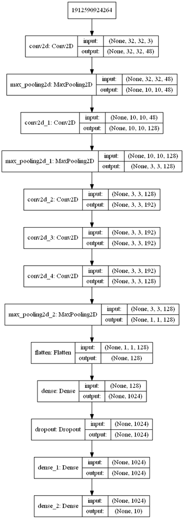

```python
tf.keras.utils.plot_model(model, to_file='small_lenet.png', show_shapes=True, show_layer_names=True)
display.display(display.Image('small_lenet.png'))
```

### Training and Validating the model

In the last practical we wrote out the dataset pipeline, loss function and training-loop to give you a good appreciation for how it works. This time, we use the training loop built-in to Keras. For simple, standard datasets like CIFAR, doing it this way will work fine, but it's important to know what goes on under the hood because you may need to write some or all of the steps out manually when working with more complex datasets!

```python
batch_size = 128
num_epochs = 10  # The number of epochs (full passes through the data) to train for

# Compiling the model adds a loss function, optimiser and metrics to track during training
model.compile(optimizer=tf.train.AdamOptimizer(),
              loss=tf.keras.losses.sparse_categorical_crossentropy,
              metrics=['accuracy'])

# The fit function allows you to fit the compiled model to some training data
model.fit(x=train_images.astype('uint8'),
          y=train_labels.astype('uint8'),
          batch_size=batch_size,
          epochs=num_epochs,
          validation_data=(validation_images.astype('uint8'), validation_labels.astype('uint8')))

print('Training complete')
```

[output not shown]

### Classifying examples

We now use our trained model to classify a sample of 25 images from the test set. We pass these 25 images to the `model.predict` function, which returns a [25, 10] dimensional matrix. The entry at position $(i, j)$ of this matrix contains the probability that image $i$ belongs to class $j$. We obtain the most-likely prediction using the `np.argmax` function which returns the index of the maximum entry along the columns. Finally, we plot the result with the prediction and prediction probability labelled underneath the image and true label on the side.

```python
img_indices = np.random.randint(0, len(test_images), size=[25])
sample_test_images = test_images[img_indices]
sample_test_labels = [cifar_labels[i] for i in test_labels[img_indices].squeeze()]

predictions = model.predict(sample_test_images)
max_prediction = np.argmax(predictions, axis=1)
prediction_probs = np.max(predictions, axis=1)
```

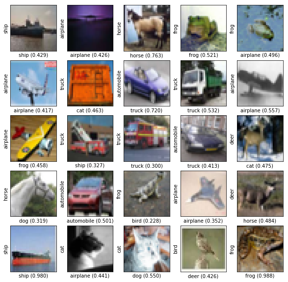

```python
img_indices = np.random.randint(0, len(test_images), size=[25])
sample_test_images = test_images[img_indices]
sample_test_labels = [cifar_labels[i] for i in test_labels[img_indices].squeeze()]

predictions = model.predict(sample_test_images)
max_prediction = np.argmax(predictions, axis=1)
prediction_probs = np.max(predictions, axis=1)


plt.figure(figsize=(10,10))
for i, (img, prediction, prob, true_label) in enumerate(
    zip(sample_test_images, max_prediction, prediction_probs, sample_test_labels)):
  plt.subplot(5,5,i+1)
  plt.xticks([])
  plt.yticks([])
  plt.grid('off')

  plt.imshow(img)
  plt.xlabel('{} ({:0.3f})'.format(cifar_labels[prediction], prob))
  plt.ylabel('{}'.format(true_label))
```

### Aside: Uncertainty in deep learning

Deep neural networks are not considered to be very good at estimating the uncertainty in their predictions. However, knowing your model's uncertainty can be very important for many applications. For example, consider a deep learning tool for diagnosing diseases, in this case a false negative could have massive impacts on a person's life! We would really like to know how confident our model is in its prediction. This is a budding field of research, for example see [this blog](https://www.cs.ox.ac.uk/people/yarin.gal/website/blog_3d801aa532c1ce.html) for a nice introduction.

### Aside: CNN architectures

Deciding on the architecture for a CNN, i.e. the combination of convolution, pooling, dense, and other layers, can be tricky and often can seem arbitrary. On top of that, one also has to make decisions such as what kind of pooling, which activation functions, and what size of convolution to use, among other things. For new and old practitioners of deep learning, these choices can be overwhelming.

However, by examining existing successful CNN architectures we can learn a lot about what works and what doesn't. (We can even apply these existing architectures to our problems since many deep learning libraries, such as TensorFlow and Keras, have them [built in](https://keras.io/applications/#available-models) and it is even possible to fine-tune pre-trained models to our specific problem using [transfer learning](https://cs231n.github.io/transfer-learning/).)

[This article](https://medium.com/@sidereal/cnns-architectures-lenet-alexnet-vgg-googlenet-resnet-and-more-666091488df5) describes many of the most successful CNN architectures in recent years, including [ResNet](https://arxiv.org/abs/1512.03385), [Inception](https://arxiv.org/pdf/1512.00567v3.pdf) and [VGG](https://arxiv.org/pdf/1409.1556.pdf). For a more detailed and technical description of these models and more see [these slides](http://cs231n.stanford.edu/slides/2017/cs231n_2017_lecture9.pdf). Reading through these resources should give you insights into why these architectures are successful as well as best practices and current trends for CNNs that will help you design your own architectures.

## Your Tasks

1. Experiment with the network architecture, try changing the numbers, types and sizes of layers, the sizes of filters, using different padding etc. How do these decisions affect the performance of the model? In particular, try building a *fully convolutinoal* network, with no (max-)pooling layers.
2. Implement BATCH NORMALISATION ([Tensorflow documentation](https://www.tensorflow.org/api_docs/python/tf/keras/layers/BatchNormalization) and [research paper](http://proceedings.mlr.press/v37/ioffe15.pdf)) to improve the model's generalisation.
3. Why do modern architectures use less max-pooling?
4. What does a 1x1 convolution do?
5. What is a residual connection?

## Additional Resources for your own time

Here's some more information on ConvNets:

- Chris Colah's blog post on [Understanding Convolutions](https://colah.github.io/posts/2014-07-Understanding-Convolutions/)
- [How do convolutional neural networks work?](http://brohrer.github.io/how_convolutional_neural_networks_work.html)
- The [CS231n course](https://cs231n.github.io/)
- [Building blocks of interpretability](https://distill.pub/2018/building-blocks/)

```python
train_images.shape
```

```
(40000, 32, 32, 3)
```

```python
def model_initializer(pading, activation,SIZE, filters_main, other_filters, maxpooling=False ):
    '''this function initial a model, the parameter will provided respectively by the user.
    the function can generate a model with or with maxpooling layer (provided that the user specify True for pooling or False without it) '''


    #check if the maxpooling is set to true of not (if True we add the pooling layer to our CNN)
    if maxpooling  == True:
        #if so build the model with maxpooling layers
        model_= tf.keras.models.Sequential([
            tf.keras.layers.Conv2D(filters=filters_main, kernel_size=SIZE, activation=activation, input_shape=(32, 32, 3), padding=pading),
            tf.keras.layers.MaxPooling2D(pool_size=SIZE),
            tf.keras.layers.Conv2D(filters=other_filters, kernel_size=SIZE, activation=activation, padding=pading),
            tf.keras.layers.MaxPooling2D(pool_size=SIZE),
            tf.keras.layers.Conv2D(filters=other_filters, kernel_size=SIZE, activation=activation, padding=pading),
            tf.keras.layers.Conv2D(filters=other_filters, kernel_size=SIZE, activation=activation, padding=pading),
            tf.keras.layers.Conv2D(filters=other_filters, kernel_size=SIZE, activation=activation, padding=pading),
            tf.keras.layers.MaxPooling2D(pool_size=SIZE),
        ])



    # else ( whether maxpooling  specify true or left empty we run the CNN without maxpooling layers)
    else:
        #we
        model_ = tf.keras.models.Sequential([
            tf.keras.layers.Conv2D(filters=filters_main, kernel_size=SIZE, activation=activation, input_shape=(32, 32, 3), padding=pading),

            #we also going to add in so batchnormalization layers (based on number of research it's believed to speed up the training process and increase accuracy)

            tf.keras.layers.BatchNormalization(),
            tf.keras.layers.Conv2D(filters=other_filters, kernel_size=SIZE, activation=activation, padding=pading),

            tf.keras.layers.BatchNormalization(),


            tf.keras.layers.Dropout(rate=0.5),


            tf.keras.layers.Flatten(),  # Flatten ("squeezes") a 3-D volume down into a single vector.
            tf.keras.layers.Dense(10, activation=tf.nn.softmax),




        ])

    return model_
```

```python
#create a function to visualize the model
def visualize_model(model):

    #this straight forward as it looks, we start by creating the picture and display it
    tf.keras.utils.plot_model(model, to_file='small_lenet.png', show_shapes=True, show_layer_names=True)
    display.display(display.Image('small_lenet.png'))
```

```python
#initialize the parameter to avoid uncessary mistake

SIZE=(1,1)
filters_main=5
pading = 'valid'
activation = 'relu'
other_filters =192
model_ = model_initializer(pading, activation,SIZE, filters_main, other_filters, maxpooling=True )
```

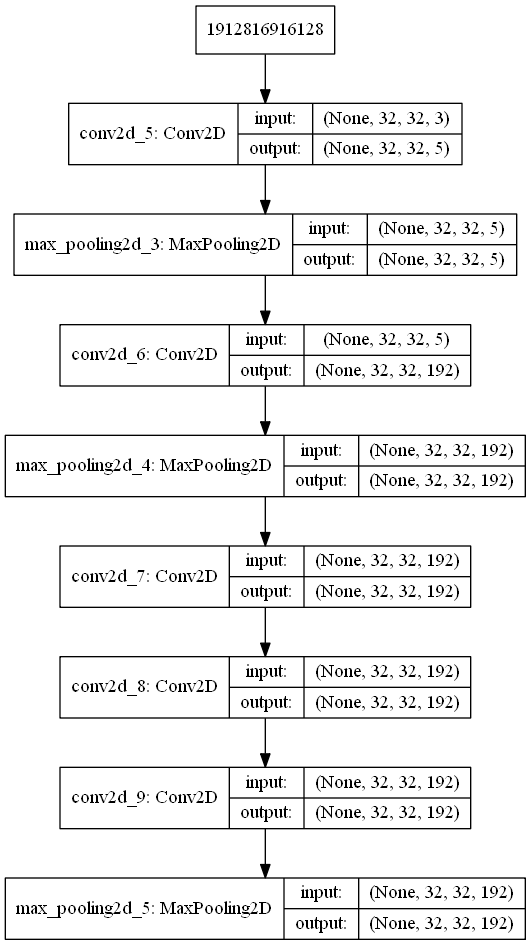

```python
visualize_model(model_)
```

## when we use 1x1 convolution we notice that the presence of maxpooling is useless and this is because. this because we're sendin an array of size 1x1 to max pooling in other works we're telling it to choose between 1 and 1

```python
#look at the work in the background thhrough the summary methoda
model_.summary()
```

```
_________________________________________________________________
Layer (type)                 Output Shape              Param #
=================================================================
conv2d_5 (Conv2D)            (None, 32, 32, 5)         20
_________________________________________________________________
max_pooling2d_3 (MaxPooling2 (None, 32, 32, 5)         0
_________________________________________________________________
conv2d_6 (Conv2D)            (None, 32, 32, 192)       1152
_________________________________________________________________
max_pooling2d_4 (MaxPooling2 (None, 32, 32, 192)       0
_________________________________________________________________
conv2d_7 (Conv2D)            (None, 32, 32, 192)       37056
_________________________________________________________________
conv2d_8 (Conv2D)            (None, 32, 32, 192)       37056
_________________________________________________________________
conv2d_9 (Conv2D)            (None, 32, 32, 192)       37056
_________________________________________________________________
max_pooling2d_5 (MaxPooling2 (None, 32, 32, 192)       0
=================================================================
Total params: 112,340
Trainable params: 112,340
Non-trainable params: 0
_________________________________________________________________
```

```python
batch_size = 128
num_epochs = 10  # The number of epochs (full passes through the data) to train for

# Compiling the model adds a loss function, optimiser and metrics to track during training
model_.compile(optimizer=tf.train.AdamOptimizer(),
              loss=tf.keras.losses.sparse_categorical_crossentropy,
              metrics=['accuracy'])

# The fit function allows you to fit the compiled model to some training data
model_.fit(x=train_images.astype('uint8'),
          y=train_labels.astype('uint8'),
          batch_size=batch_size,
          epochs=num_epochs,
          validation_data=(validation_images.astype('uint8'), validation_labels.astype('uint8')))

print('Training complete')
```

[output not shown]